# Fitting Tensor Autoregression Models with ToTR

# Introduction

This vignette demonstrates how to fit tensor autoregression models using the `totr` package under two coefficient structures:

- **OP**: outer-product coefficient format (see (Llosa-Vite and Maitra 2022) and (Hoff 2015))
- **CP**: CANDECOMP/PARAFAC coefficient format (see (Llosa-Vite and Maitra 2022) and (Lock 2018))

The data we will use corresponds to a 4-way tensor time series of dimensions

$$25 \times 25 \times 4 \times 548,$$

where the modes represent:

- 25 sender countries,
- 25 receiver countries,
- 4 CAMEO event category,
- 548 weeks (between 2004-2014).

The data file `icews_tensor_data.tns`:

- stores this tensor time series data in a sparse tensor `.tns` format (Sandia National Laboratories 2026)
- was generated as part of the gtotr python package (Llosa-Vite and Dunlavy 2026b)
- was used in the ptotr manuscript (Llosa-Vite and Dunlavy 2026a)
- was generated exactly as described in (Hoff 2015)

Below we read the data.

```r
read_sptensor_toarray <- function(filename) {
  lines <- readLines(filename)
  dims <- as.integer(strsplit(trimws(lines[3]), "\\s+")[[1]])
  dat  <- read.table(text = lines[-(1:4)], header = FALSE)
  arr <- array(0, dim = dims)
  arr[as.matrix(dat[, 1:4])] <- dat[, 5]
  arr
}

Z <- read_sptensor_toarray("icews_tensor_data.tns")
```

This example illustrates:

- how to construct tensor autoregression inputs from the raw data,
- how to fit OP and CP tensor-on-tensor regression models,
- how to compare fitted models using loglikelihood and BIC.

# Constructing the autoregression tensors

From the tensor time series `Z` constructed above, we construct an autoregression in which the predictors `X` include:

1. the lag-1 tensor (1-week dependence),
2. the average of lags 2 through 5 (1-month dependence),
3. an intercept channel (mean trend).

The response `Y` is the tensor at the next week.

```r
X <- array(0, c(25, 25, 9, 543))
X[, , 1:4, ] <- Z[, , , 5:547]  # lag 1
X[, , 5:8, ] <- (
  Z[, , , 1:543] +
    Z[, , , 2:544] +
    Z[, , , 3:545] +
    Z[, , , 4:546]
) / 4                            # average of lags 2 through 5
X[, , 9, ] <- 1                 # intercept channel

Y <- Z[, , , 6:548]

dim(X)
```

```
#> [1]  25  25   9 543
```

```r
dim(Y)
```

```
#> [1]  25  25   4 543
```

The predictor tensor `X` has dimensions

$$25 \times 25 \times 9 \times 543,$$

and the response tensor `Y` has dimensions

$$25 \times 25 \times 4 \times 543.$$

# OP tensor autoregression models

OP ties one predictor mode to one response mode, so permuting modes changes the separability assumption. Therefore, for OP regression, different permutations of the predictor modes produce different models. Since `X` has three modes, there are $3! = 6$ possible permutations.

For simplicity, in all fits below we use the independent-error covariance structure by setting `corrs = "independent"`. We will also run multiple initializations because of the non-convexity of the objective.

```r
perms <- rbind(
  c(1, 2, 3),
  c(1, 3, 2),
  c(2, 1, 3),
  c(2, 3, 1),
  c(3, 1, 2),
  c(3, 2, 1)
)

op_res <- vector("list", nrow(perms))
n <- dim(Y)[4]
nit <- 100
ninit <- 10

set.seed(0)
for (i in 1:nrow(perms)) {
  perm <- perms[i, ]
  Xp <- aperm(X, c(perm, 4))

  best_fit <- NULL
  best_ll <- -Inf
  best_j <- NA_integer_

  for (jj in 1:ninit) {
    fit_try <- OP_normal(
      Yall = Y,
      Xall = Xp,
      it = nit,
      corrs = "independent"
    )

    ll_try <- tail(fit_try$allik, 1)

    if (ll_try > best_ll) {
      best_ll <- ll_try
      best_fit <- fit_try
      best_j <- jj
    }
  }

  hs <- dim(Xp)[1:3]
  ms <- dim(Y)[1:3]

  op_res[[i]] <- data.frame(
    model = "OP",
    permutation = paste(perm, collapse = "-"),
    rank = NA,
    loglik = best_ll,
    npar = sum(hs * ms - 1) + 2,
    init_best = best_j,
    stringsAsFactors = FALSE
  )
}

op_res <- do.call(rbind, op_res)
op_res$bic <- -2 * op_res$loglik + log(n) * op_res$npar
write.csv(op_res, file = "op_res.csv", row.names = FALSE)

op_res
```

```
#>   model permutation rank   loglik npar init_best      bic
#> 1    OP       1-2-3   NA -4903209 1285         5  9814509
#> 2    OP       1-3-2   NA -5378512  949         7 10762999
#> 3    OP       2-1-3   NA -4944013 1285         6  9896118
#> 4    OP       2-3-1   NA -5379506  949         6 10764987
#> 5    OP       3-1-2   NA -5370144  949         6 10746264
#> 6    OP       3-2-1   NA -5362944  949         5 10731863
```

The OP parameter count used here is

$$\sum_k (h_k m_k - 1) + 2,$$

where one degree of freedom is removed for proportional indeterminacy and the additional 2 accounts for the remaining scale term and $\sigma^2$.

# CP tensor autoregression models

We now fit CP tensor autoregression models over a range of ranks.

```r
cp_ranks <- 1:30
cp_res <- vector("list", length(cp_ranks))

hs <- dim(X)[1:3]
ms <- dim(Y)[1:3]

set.seed(0)
for (ii in seq_along(cp_ranks)) {
  R <- cp_ranks[ii]

  best_fit <- NULL
  best_ll <- -Inf
  best_j <- NA_integer_

  for (jj in 1:ninit) {
    fit_try <- CP_normal(
      Yall = Y,
      Xall = X,
      R = R,
      it = nit,
      corrs = "independent"
    )

    ll_try <- tail(fit_try$allik, 1)

    if (ll_try > best_ll) {
      best_ll <- ll_try
      best_fit <- fit_try
      best_j <- jj
    }
  }

  cp_res[[ii]] <- data.frame(
    model = "CP",
    permutation = NA,
    rank = R,
    loglik = best_ll,
    npar = R * (sum(hs - 1) + sum(ms - 1) + 1) + 1,
    init_best = best_j,
    stringsAsFactors = FALSE
  )
}

cp_res <- do.call(rbind, cp_res)
cp_res$bic <- -2 * cp_res$loglik + log(n) * cp_res$npar
write.csv(cp_res, file = "cp_res.csv", row.names = FALSE)

cp_res
```

```
#>    model permutation rank   loglik npar init_best      bic
#> 1     CP          NA    1 -5622712  109        10 11246110
#> 2     CP          NA    2 -5509319  217         7 11020005
#> 3     CP          NA    3 -5426221  325         6 10854489
#> 4     CP          NA    4 -5371627  433         6 10745981
#> 5     CP          NA    5 -5325599  541         7 10654605
#> 6     CP          NA    6 -5282541  649         6 10569170
#> 7     CP          NA    7 -5243251  757         9 10491269
#> 8     CP          NA    8 -5209786  865         9 10425019
#> 9     CP          NA    9 -5180113  973         2 10366354
#> 10    CP          NA   10 -5141831 1081         7 10290470
#> 11    CP          NA   11 -5119181 1189        10 10245849
#> 12    CP          NA   12 -5093066 1297         1 10194300
#> 13    CP          NA   13 -5073686 1405         6 10156220
#> 14    CP          NA   14 -5057199 1513         3 10123926
```

[output cut: 16 more lines]

The CP parameter count used here is

$$R \left( \sum_k (h_k - 1) + \sum_k (m_k - 1) + 1 \right) + 1,$$

where the reduction by 1 per factor reflects proportional indeterminacy, the term inside the parentheses includes one component weight per rank, and the final $+1$ accounts for $\sigma^2$.

# Comparing OP and CP fits

We can combine the fitted OP and CP summaries into a single table.

```r
res <- rbind(cp_res, op_res)
res[order(res$bic), ]
```

```
#>    model permutation rank   loglik npar init_best      bic
#> 30    CP        <NA>   30 -4836110 3241         5  9692630
#> 28    CP        <NA>   28 -4843521 3025        10  9706091
#> 29    CP        <NA>   29 -4846100 3133         9  9711928
#> 27    CP        <NA>   27 -4850667 2917         4  9719702
#> 26    CP        <NA>   26 -4858987 2809         1  9735662
#> 25    CP        <NA>   25 -4872982 2701         4  9762972
#> 24    CP        <NA>   24 -4892259 2593         1  9800846
#> 23    CP        <NA>   23 -4896861 2485        10  9809371
#> 31    OP       1-2-3   NA -4903209 1285         5  9814509
#> 22    CP        <NA>   22 -4913999 2377        10  9842967
#> 21    CP        <NA>   21 -4922494 2269         1  9859275
#> 33    OP       2-1-3   NA -4944013 1285         6  9896118
#> 20    CP        <NA>   20 -4942151 2161         4  9897910
#> 19    CP        <NA>   19 -4961873 2053         4  9936675
```

[output cut: 22 more lines]

This table provides, for each fitted model:

- the model type,
- the permutation used for OP fits,
- the rank used for CP fits,
- the fitted loglikelihood,
- the number of free parameters,
- the resulting BIC.

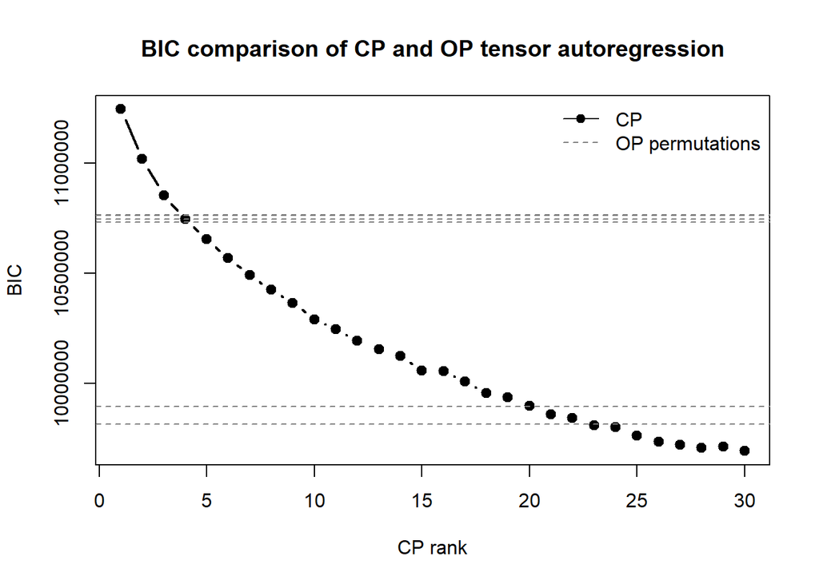

```r
plot(cp_res$rank, cp_res$bic,
     type = "b", pch = 19, lwd = 2,
     xlab = "CP rank", ylab = "BIC",
     main = "BIC comparison of CP and OP tensor autoregression")

abline(h = op_res$bic, lty = 2, col = "gray50")

legend("topright",
       legend = c("CP", "OP permutations"),
       lty = c(1, 2),
       pch = c(19, NA),
       col = c("black", "gray50"),
       bty = "n")
```

# Remarks

This example shows how `totr` can be used for autoregressive modeling of tensor time series under different coefficient structures.

- **OP models** impose a fully separable coefficient structure.
- **CP models** allow sums of separable components and therefore offer greater flexibility as rank increases.

The BIC comparison provides a practical way to balance model fit and complexity when comparing these structured tensor regression models.

In particular, among the six OP models, higher parameter counts are associated with lower BIC values, suggesting that the fully separable structure may be too restrictive for these data. In contrast, the CP model includes a rank parameter that provides a flexible tradeoff between fit and complexity. Larger CP ranks generally improve the fit, but the incremental improvement in BIC diminishes as the rank increases.

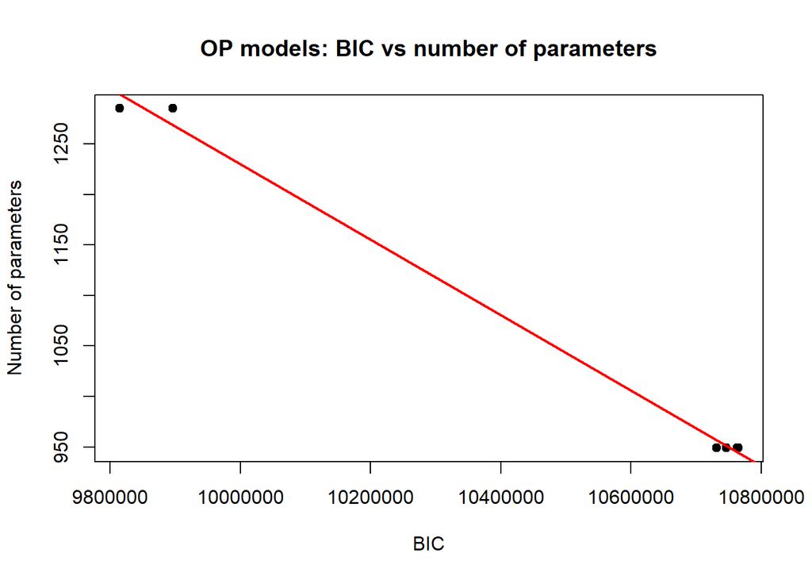

```r
plot(op_res$bic, op_res$npar,
     xlab = "BIC",
     ylab = "Number of parameters",
     pch = 19,
     main = "OP models: BIC vs number of parameters")
abline(lm(npar ~ bic, data = op_res), col = "red", lwd = 2)
```

# References

Hoff, Peter D. 2015. “Multilinear Tensor Regression for Longitudinal Relational Data.” *The Annals of Applied Statistics* 9 (3): 1169–93.

Llosa-Vite, Carlos, and Daniel M. Dunlavy. 2026a. “Poisson-Response Tensor-on-Tensor Regression and Applications.” https://doi.org/10.48550/arXiv.2604.07377.

Llosa-Vite, Carlos, and Danny Dunlavy. 2026b. *Gtotr: Generalized Tensor-on-Tensor Regression*. https://gtotr.readthedocs.io/.

Llosa-Vite, Carlos, and Ranjan Maitra. 2022. “Reduced-Rank Tensor-on-Tensor Regression and Tensor-Variate Analysis of Variance.” *IEEE Transactions on Pattern Analysis and Machine Intelligence* 45 (2): 2282–96.

Lock, Eric F. 2018. “Tensor-on-Tensor Regression.” *Journal of Computational and Graphical Statistics* 27 (3): 638–47.

Sandia National Laboratories. 2026. *Pyttb: Python Tensor Toolbox*. https://pyttb.readthedocs.io/.